# Risk based evaluations of competing agronomic climate adaptation strategies: Workflow example for rice planting strategies from crop growth simulation evidence

Author

Maxwell Mkondiwa, Anton Urfels and Terry Hurley

# 1 Introduction

This notebook presents a novel approach for developing and targeting robust recommendations from crop simulation, long term experiments or multi-season survey data based on a risk optimization model.

For the computational model, Terry Hurley at University of Minnesota wrote the first Matlab code from which we have adapted to Octave and R.

To reproduce the analyses, one requires Octave installation. You can download Octave from here: https://octave.org/download.

# 2 Stylized example

In order to run this step, one needs to install Octave. The folder should contain the different functions that used for the optimization including CreateWTPBoundsbyCell and CreateTableData.

## 2.1 Stochastic dominance analysis using graphics

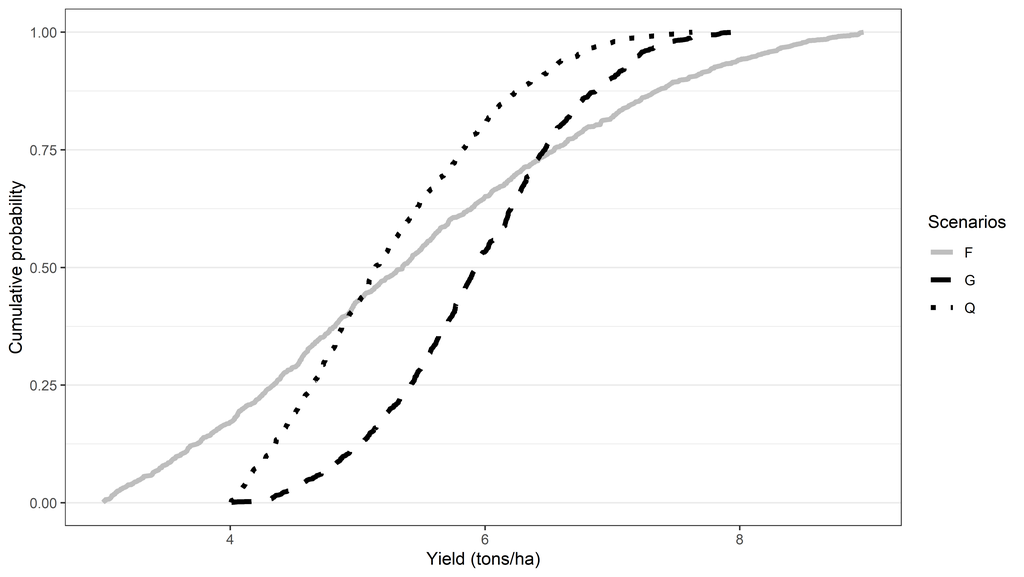

```r
# Hypothetical Comparisons ---------------------------------------------------

# Theoretical graphs ------------------------------------------------------------

# Truncated normal -----------------------
library(truncnorm)
g <- rtruncnorm (n=1000,a=4,b=8, mean=6,sd=0.8 )
q <- rtruncnorm (n=1000,a=4,b=8, mean=5,sd=1 )
f <- rtruncnorm (n=1000,a=3,b=9, mean=5,sd=2 )
df <- data.frame(x = c(g, q, f),Scenarios = factor(rep(c("G","Q","F"), c(1000,1000,1000))))
df <- df[order(df$x), ]

df$ecdf <- ave(df$x, df$Scenarios, FUN=function(x) seq_along(x)/length(x))

library(ggplot2)
stochasticdominance=ggplot(df, aes(x, ecdf, colour =   Scenarios,linetype=Scenarios)) +
  geom_line(lwd=c(1.5))+
  scale_linetype_manual(values = c(1,2,3))+
  # theme(axis.ticks = element_blank(),axis.text.x = element_blank()) +
  xlab("Yield (tons/ha)") +
  ylab("Cumulative probability") +
  scale_color_manual(values = c("grey","black","black"))+
  theme(panel.grid.major.x = element_blank())+
  theme(panel.grid.minor.x = element_blank())
previous_theme <- theme_set(theme_bw())
stochasticdominance
```

## 2.2 Clean data for octave

```r
library(rio)

library(rio)
ID=rep(1,1000)
g=as.data.frame(g*1000)
q=as.data.frame(q*1000)
f=as.data.frame(f*1000)
Rep=1:nrow(g)
Area=rep(1,1000)


QvsG=data.frame(ID,Rep,Area,q,g)
export(QvsG,colNames=F,"QvsG.xlsx")
QvsG=as.matrix(QvsG)
colnames(QvsG) <- c(1,2,3,4,5)

library(rhdf5)
h5save(QvsG,file="QvsG.hdf")

QvsF=data.frame(ID,Rep,Area,q,f)
export(QvsF,colNames=F,"QvsF.xlsx")
QvsF=as.matrix(QvsF)
colnames(QvsF) <- c(1,2,3,4,5)
h5save(QvsF,file="QvsF.hdf")


FvsG=data.frame(ID,Rep,Area,f,g)
export(FvsG,colNames=F,"FvsG.xlsx")
FvsG=as.matrix(FvsG)
colnames(FvsG) <- c(1,2,3,4,5)
h5save(FvsG,file="FvsG.hdf")


# Experiments -------------

# G vs Q: Q as baseline -----------------
GvsQ=data.frame(ID,Rep,Area,g,q)
export(GvsQ,colNames=F,"GvsQ.xlsx")
GvsQ=as.matrix(GvsQ)
colnames(GvsQ) <- c(1,2,3,4,5)
h5save(GvsQ,file="GvsQ.hdf")

## F vs Q: Q as baseline ---------------
FvsQ=data.frame(ID,Rep,Area,f,q)
export(FvsQ,colNames=F,"FvsQ.xlsx")
FvsQ=as.matrix(FvsQ)
colnames(FvsQ) <- c(1,2,3,4,5)
h5save(FvsQ,file="FvsQ.hdf")


## G vs F: F as baseline ----------------
GvsF=data.frame(ID,Rep,Area,g,f)
export(GvsF,colNames=F,"GvsF.xlsx")
GvsF=as.matrix(GvsF)
colnames(GvsF) <- c(1,2,3,4,5)
h5save(GvsF,file="GvsF.hdf")
```

## 2.3 Q vs G

```matlab
load -hdf5 "QvsG.hdf"

ndataseq01060216=QvsG

whos

CreateWTPBoundsbyCell

save -hdf5 "RA.hdf"





#xlswrite('RA_GvsQ_fromR',RA)
#xlswrite('DescriptiveStat_GvsQ_fromR.xlsx',DescriptiveStat)
```

[output not shown]

[output cut: 980 more lines]

[output not shown]

#### 2.3.0.1 Calculate descriptive statistics

```matlab
load -hdf5 "RA.hdf"


CreateTableData


DescriptiveStat2=DescriptiveStat
```

```
DescriptiveStat2 =

  -4.0454e-03
            0
  -1.0000e+08
  -1.0000e+06
  -1.0000e+06
  -1.0000e+06
  -1.0000e+06
  -1.0000e+06
  -1.0000e+08
  -7.1467e-01
            0
  -1.0000e+08
  -1.0000e+06
  -1.0000e+06
  -1.0000e+06
  -1.0000e+06
  -1.0000e+06
  -1.0000e+08
            0
            0
   1.0000e+00
   1.0000e+00
   1.0000e+00
```

# 3 Bihar Model Application

The example above has shown for a case where there is one location in which there are multiple years of data. In the case of when one has run a crop growth model and has ncdf4 outputs, then one can use the same approach to estimate the model for the whole state.

# 4 Conclusion

# 5 References

Hurley, T., Koo, J., & Tesfaye, K. (2018). Weather risk: how does it change the yield benefits of 395 nitrogen fertilizer and improved maize varieties in sub-Saharan Africa? Agricultural 396 Economics, 49(6), 711-723. https://doi.org/https://doi.org/10.1111/agec.12454.

Levy, H. (2006). Stochastic Dominance: Investment Decision Making Under Uncertainty (Second Edition). Springer. New York, NY.Pages 180-182.

Mkondiwa, M., and Urfels, A. 2023. “Risk-based evaluations of competing agronomic climate adaptation strategies: The case of rice planting strategies in the Indo Gangetic Plains”. Working Paper.